# HW3 - Raport

Grzegorz Zakrzewski

### Badany problem

W ramach tej pracy domowej zamierzam sprawdzić, czy słupki na wykresach kolumnowych 3D porównuje się gorzej niż słupki na wykresach kolumnowych 2D.

### Przygotowany eksperyment

Na podstawie danych statystycznych dotyczących:

- powierzchni siedmu wybranych polskich miast ([źródło](https://pl.wikipedia.org/wiki/Dane_statystyczne_o_miastach_w_Polsce));
- powierzchni sześciu wybranych polskich województw ([źródło](https://pl.wikipedia.org/wiki/Wojew%C3%B3dztwo));
- średniej temperatury miesięcznej we Wrocławiu w latach 2018, 2019 i 2020 ([źródło](https://meteomodel.pl/dane/srednie-miesieczne/?imgwid=351160424&par=tm));

przygotowałem trzy niewielki ramki danych, które prezentują się następująco:

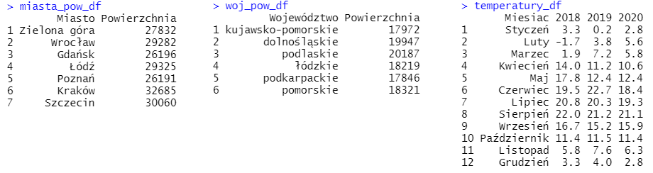

Dla każdej przygotowanej ramki danych przygotowałem po dwa wykresy, kolumnowy 2D i kolumnowy 3D. Wykresy 2D wykonałem za pomocą biblioteki ggplot, natomiast wykresy 3D za pomocą programu Microsoft Excel. Wyglądają one tak:

#### Powierzchnia miast

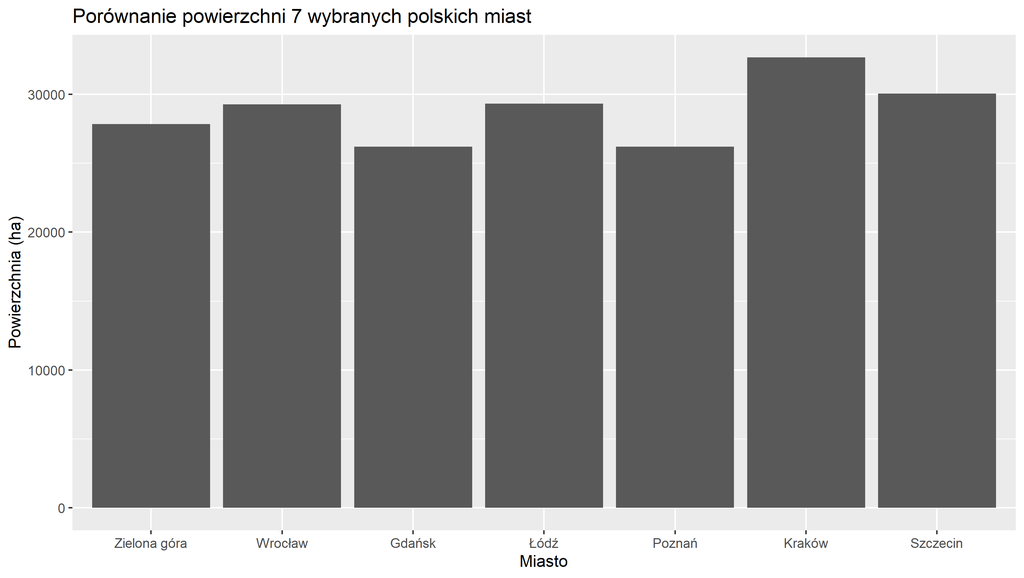

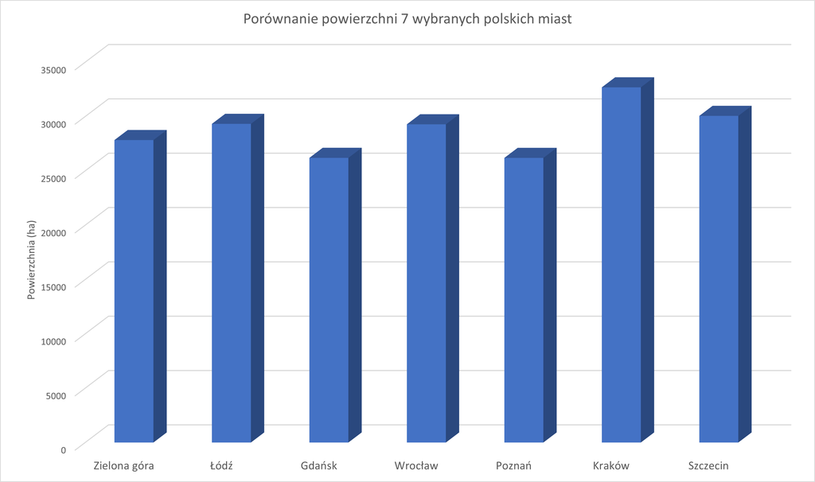

#### Powierzchnia województw

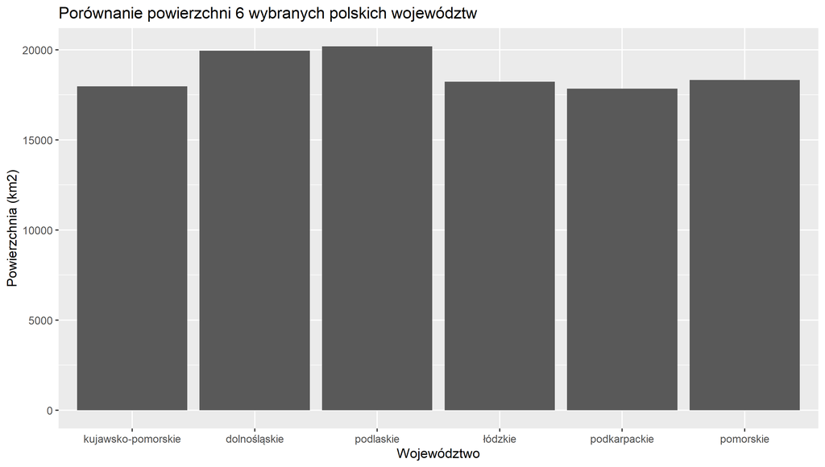

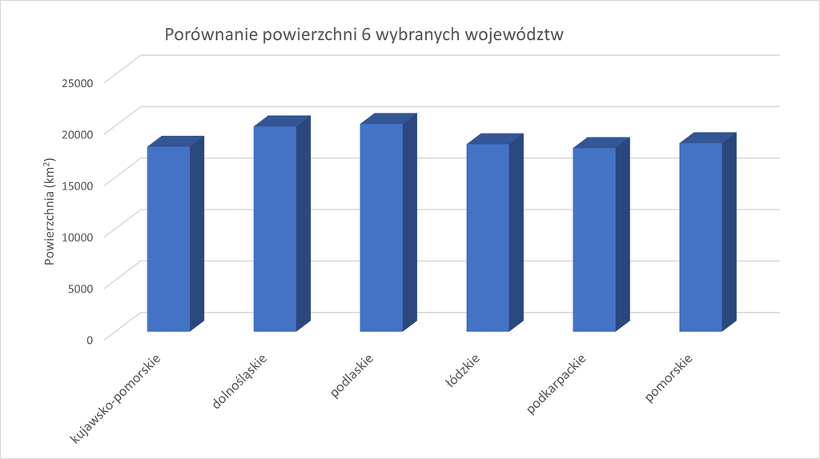

#### Średnia temperatura

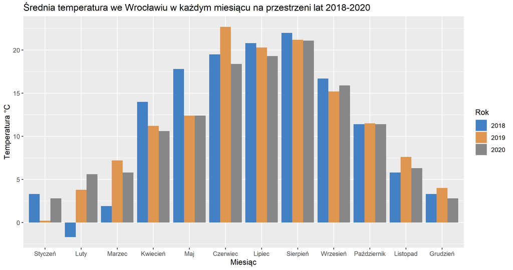

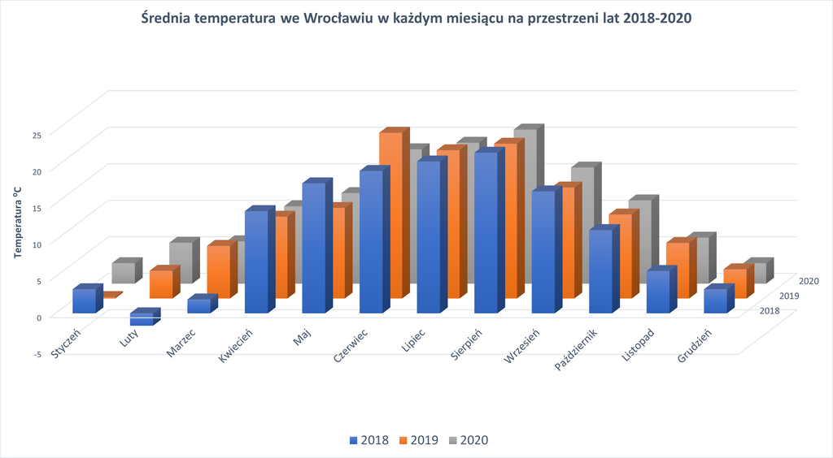

Zależało mi na przedstawieniu realnie występujących danych o zbliżonych wartościach.

### Przeprowadzenie ankiet

Udało się przeprowadzić 15 ankiet. Swoim ankieterom pokazywałem kolejno wykresy.

W przypadku wykresów dotyczących powierzchni miasta lub województwa, pokazywałem wykres 3D lub 2D i prosiłem o posortowanie wartości od największej do najmniejszej. W szczególności zależało mi na określeniu relacji między jednostkami o naprawdę bliskiej powierzchni, na przykład czy Poznań jest większy niż Gdańsk lub czy województwo pomorskie jest wieksze od łódzkiego. Każda każda jednostka na poprawnej pozycji jest liczona jako jeden punkt.

W przypadku danych dotyczących średniej temperatury miałem przygotowny zestaw krótkich pytań:

- cieplej było w kwietniu 2019 czy 2020 roku?
- w którym roku był najcieplejszy lipiec? a najzimniejszy?
- w którym roku był najcieplejszy październik? a najzimniejszy?
- cieplej było w kwietniu 2020 czy maju 2019?
- cieplej było w lipcu 2020 czy maju 2018?
- cieplej było w lutym 2020 czy marcu 2018?

dotyczący relacji między słupkami, które na pierwszy rzut oka wydają się naprawdę bliskie. Przy każdym pytaniu pokazywałem wykres 2D lub 3D. Odpowiedź mogła być prawidłowa albo błędna. Każdemu ankieterowi zadawałam co najmniej 3 pytania z zestawu.

### Wyniki ankiet

Wyniki ankiet nie okazały się być zaskoczeniem.

#### Wykresy dotyczące powierzchni

Przy wykresach dotyczących powierzchni każde miasto / województwo na poprawniej pozycji było liczone jako jeden punkt. Na tej podstawie zsumowałem punkty zdobyte przez wykresy 2D i 3D oraz policzyłem, jaka część odpowiedzi była poprawna. Wyniki prezentują się następująco:

| Jednostka | Typ wykresu | Zdobyte punkty | Do zdobycia |
| --- | --- | --- | --- |
| Miasta | 2D | 38 | 56 |
| Miasta | 3D | 39 | 70 |
| Województwa | 2D | 42 | 54 |
| Województwa | 3D | 29 | 48 |

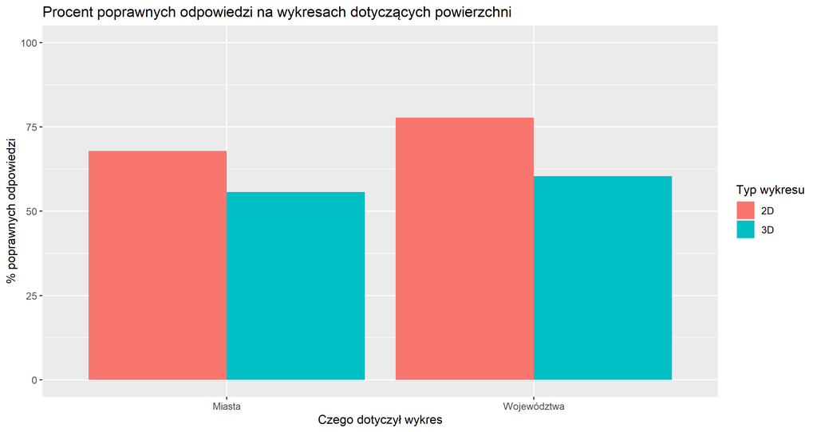

#### Wykres dotyczący temperatury

Przy pytaniach dotyczących temperatur odpowiedź była liczona jako poprawna lub błędna. Wyniki prezentują się natępująco:

| Typ wykresu | Poprawne | Bledne | Procent poprawnych |
| --- | --- | --- | --- |
| 2D | 41 | 7 | 85.4 |
| 3D | 26 | 18 | 59.1 |

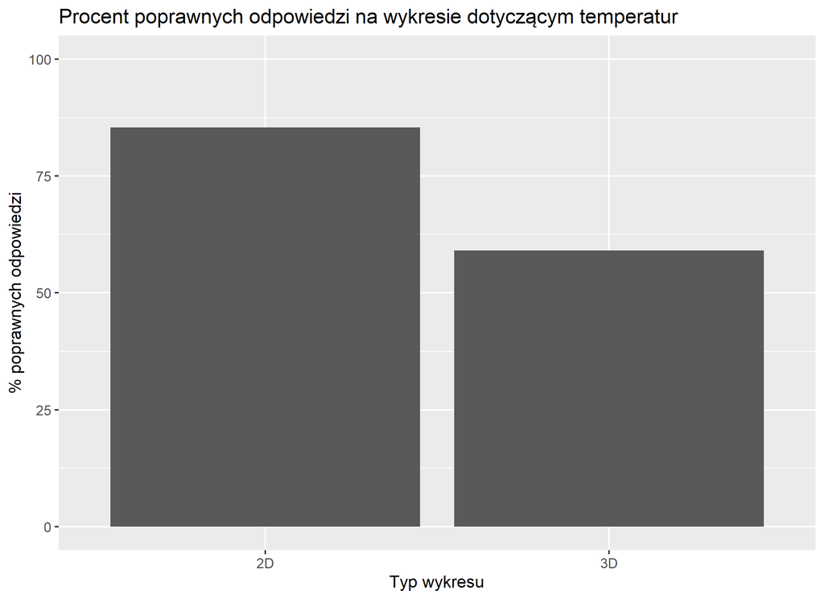

### Podsumowanie

Przeprowadzone badania wykazały, że słupki na wykresach 3D porównuje się gorzej niż słupki na wykresach 2D. Największe problemy pojawiają się przy porównywaniu słupków o zbliżonych wysokościach - wtedy patrząc na wykres 3D nie możemy mieć praktycznie żadnej pewności. Jednakże, na wykresach 2D również pojawiały się wtedy pewne trudności, lecz były one znacząco mniejsze.

Podsumowując, “dobra praktyka” polegająca na wykorzystywaniu wykresów 2D faktycznie działa.

#### Załączniki

Poniżej zamieszczam kod wykorzystany do wygenerowania wszystkich wykresów za pomocą biblioteki `ggplot`.

```r
library(tidyverse)

## Powierzchnia miast

miasta_pow_df <- read.csv2("miasta_pow.csv")

miasta_pow_df %>%
  ggplot(aes(x = fct_inorder(Miasto), y = Powierzchnia)) +
  geom_col() +
  labs(
    title = "Porównanie powierzchni 7 wybranych polskich miast",
    x = "Miasto",
    y = "Powierzchnia (ha)"
  )

## Powierzchnia województw

woj_pow_df <- read.csv2("woj_pow.csv")

woj_pow_df %>%
  ggplot(aes(x = fct_inorder(Województwo), y = Powierzchnia)) +
  geom_col() +
  labs(
    title = "Porównanie powierzchni 6 wybranych polskich województw",
    x = "Województwo",
    y = "Powierzchnia (km2)"
  )

## Temperatury

temperatury_df <- read_csv2("temperatury.csv") %>%
  pivot_longer(!Miesiac, names_to = "Rok", values_to = "Temperatura")

temperatury_df %>%
  ggplot(aes(x = fct_inorder(Miesiac), y = Temperatura, fill = Rok)) +
  geom_col(position = "dodge") +
  scale_fill_manual(values = c("#4380c4", "#de9650", "#878787")) +
  labs(
    title = "Średnia temperatura we Wrocławiu w każdym miesiącu na przestrzeni lat 2018-2020",
    y = "Temperatura ⁰C",
    x = "Miesiąc"
  )

### Wyniki

# Powierzchnia

df <- tribble(
  ~jednostka, ~`Typ wykresu`, ~punkty, ~calosc,
  "Miasta", "2D", 38, 56,
  "Miasta", "3D", 39, 70,
  "Województwa", "2D", 42, 54,
  "Województwa", "3D", 29, 48,
)

df %>%
  mutate(procent = punkty / calosc * 100) %>%
  ggplot(aes(x = jednostka, y = procent, fill = `Typ wykresu`)) +
  geom_col(position = "dodge" ) +
  ylim(c(0, 100)) +
  labs(
    title = "Procent poprawnych odpowiedzi na wykresach dotyczących powierzchni",
    y = "% poprawnych odpowiedzi",
    x = "Czego dotyczył wykres"
    )

# Temperatura

df <- tribble(
  ~`Typ wykresu`, ~poprawne, ~bledne,
  "2D", 41, 7,
  "3D", 26, 18,
)

df %>%
  mutate(procent = poprawne / (bledne + poprawne) * 100) %>%
  ggplot(aes(x = `Typ wykresu`, y = procent)) +
  geom_col() +
  ylim(c(0, 100)) +
  labs(
    title = "Procent poprawnych odpowiedzi na wykresie dotyczącym temperatur",
    y = "% poprawnych odpowiedzi",
    x = "Typ wykresu"
  )
```